# The Limits of Human Predictions of Recidivism

Zhiyuan “Jerry” Lin, Jongbin Jung, Sharad Goel, Jennifer Skeem

This is an R Markdown recreating the plots and tables in the paper.

```r
paper_results <- read_rds(PAPER_RESULTS_RDS)
```

## Dataset Summary

| exp_name | baserate | features | # Resopnses (No needback) | # Resopnses (Feedback) |
| --- | --- | --- | --- | --- |
| COMPAS balanced BR | 48% | streamlined | 2700 | 2400 |
| COMPAS low BR | 11% | streamlined | 2400 | 3000 |
| LSI-R balanced BR | 29% | streamlined/enriched | 2850/2500 | 2700/2400 |
| LSI-R low BR | 9% | streamlined/enriched | 2850/2900 | 3000/2550 |

**Table 1**: Characteristics of the four datasets we considered (Note: “BR”" is “base rate”).

## Figures

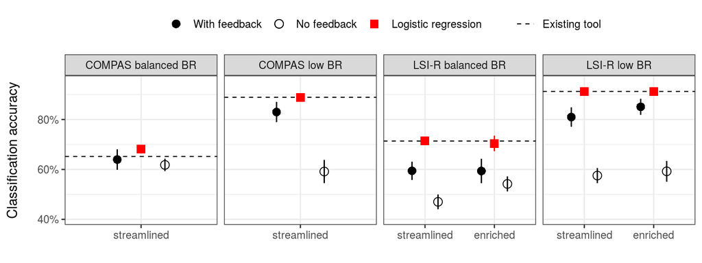

**Figure 2**: Classification accuracy of: (1) human predictions, with and without immediate feedback; (2) a logistic regression model that we trained using the same information provided to study participants; and (3) the existing tools, COMPAS or LSI-R. For participants in the feedback condition, only the last 10 responses for each participant were used, to account for the effects of learning. Error bars represent 95% confidence intervals, and are typically smaller than the height of the red square for the logistic regression models.

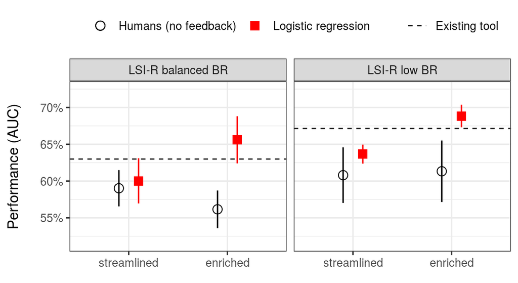

**Figure 3**: Ranking accuracy (AUC) of: (1) human predictions without feedback; (2) logistic regression models that use the same information provided to study participants; and (3) the existing LSI-R tools. Error bars indicate 95% confidence intervals.

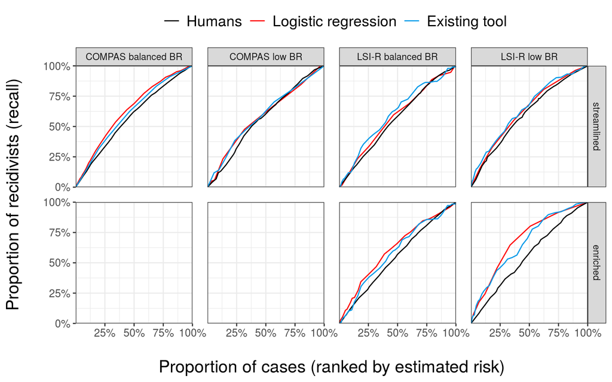

**Figure 4**: Proportion of people who recidivated that were identified when ranking by the risk assessments of humans in the no-feedback condition, a logistic regression model, and existing tools (COMPAS or LSI-R). For each value $p$ on the horizontal axis, the vertical axis shows the proportion of all recidivists that are included among the $p$-percent of the population deemed riskiest. Human performance was generally comparable to algorithmic tools in the ”streamlined“ condition (top panels), but algorithmic tools outperformed humans when more information was made available (”enriched“ condition, in the bottom panels).

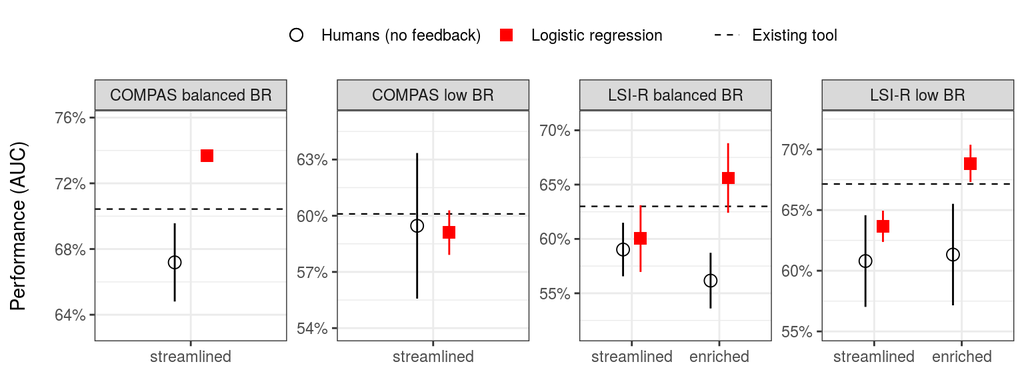

**Figure A1**: Ranking performance (AUC) of: (1) human predictions without feedback; (2) logistic regression models that use the same information provided to study participants; and (3) the existing tools, COMPAS or LSI-R. Error bars indicate 95% confidence intervals.

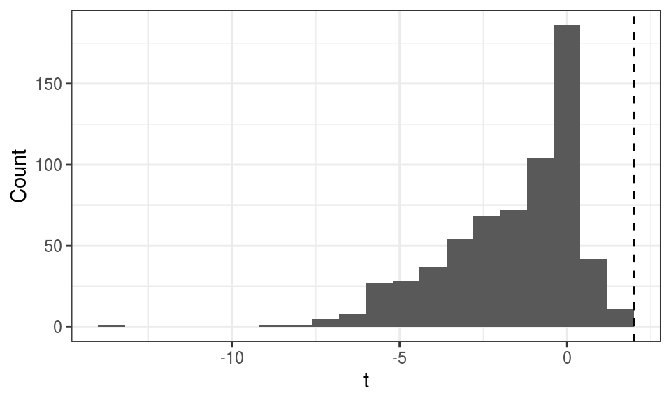

**Figure A2**: Distribution of the $t$-statistic for the difference in accuracy between humans and existing tools (COMPAS or LSI-R) across all 645 participants. The vertical dashed line is at $t=2$. None of the participants outperformed the existing tools by a statistically significant margin.

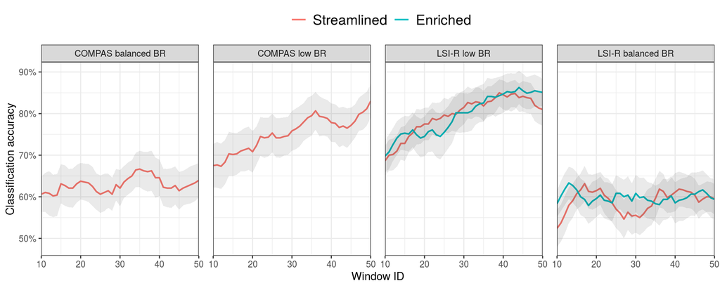

**Figure A3**: Average classification accuracy over time with feedback, for a sliding window of 10 questions, where the window ID indicates the last question of that window. Humans recalibrated as a result of feedback, and we accordingly observed increasing accuracy. The largest improvements occurred for groups with low base rates. Grey bands indicate 95% confidence intervals.

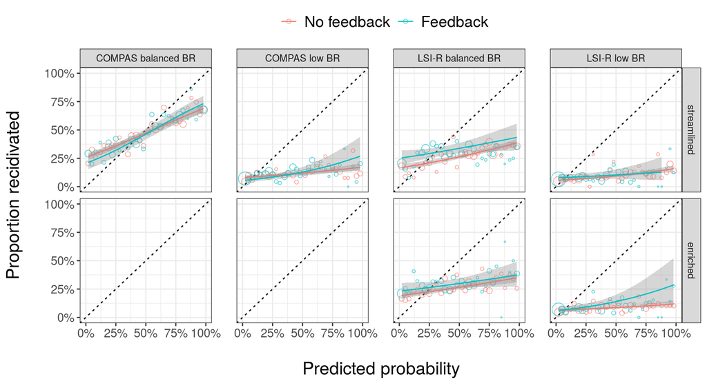

**Figure A4**: Calibration plot for human responses. Lines show a logistic regression of participants’ estimated probabilities against the actual outcomes, and indicate that human predictions suffered from poor calibration. In the feedback conditions, we restricted to the final 10 responses to adjust for learning gains. In a re-analysis of Dressel and Farid’s data, Bansak likewise found evidence of poor calibration in human predictions of recidivism.

## Tables

| features | expName | Existing tool - human diff | Model - human diff |
| --- | --- | --- | --- |
| streamlined | COMPAS balanced BR | 0.03 (0.01) | 0.06 (0.01) |
| streamlined | COMPAS low BR | 0.30 (0.02) | 0.30 (0.02) |
| streamlined | LSI-R balanced BR | 0.24 (0.02) | 0.24 (0.02) |
| streamlined | LSI-R low BR | 0.34 (0.02) | 0.34 (0.02) |
| enriched | LSI-R balanced BR | 0.17 (0.02) | 0.16 (0.02) |
| enriched | LSI-R low BR | 0.32 (0.02) | 0.32 (0.02) |

**Table A1**: Difference in classification accuracy (in percentage points) between humans without feedback and: (1) existing tools (COMPAS or LSI-R); and (2) our own logistic regression models. In all cases, the algorithms outperformed the study participants by a statistically significant margin, with the standard error of estimates in parentheses.

| features | expName | Existing tool - human diff | Model - human diff |
| --- | --- | --- | --- |
| streamlined | COMPAS balanced BR | 0.01 (0.02) | 0.04 (0.02) |
| streamlined | COMPAS low BR | 0.06 (0.02) | 0.06 (0.02) |
| streamlined | LSI-R balanced BR | 0.12 (0.02) | 0.12 (0.02) |
| streamlined | LSI-R low BR | 0.10 (0.02) | 0.10 (0.02) |
| enriched | LSI-R balanced BR | 0.12 (0.02) | 0.11 (0.03) |
| enriched | LSI-R low BR | 0.06 (0.02) | 0.06 (0.02) |

**Table A2**: Difference in classification accuracy (in percentage points) between humans with feedback and: (1) existing tools (COMPAS or LSI-R); and (2) our own logistic regression models. The algorithms outperformed humans in all cases, with bolded entries indicating statistically significant gaps and standard errors in parentheses.

| features | expName | Feedback human - human diff |
| --- | --- | --- |
| streamlined | COMPAS balanced BR | 0.02 (0.02) |
| streamlined | COMPAS low BR | 0.24 (0.03) |
| streamlined | LSI-R balanced BR | 0.12 (0.02) |
| streamlined | LSI-R low BR | 0.23 (0.03) |
| enriched | LSI-R balanced BR | 0.05 (0.03) |
| enriched | LSI-R low BR | 0.26 (0.03) |

**Table A3**: Difference in classification accuracy (in percentage points) between participants who did and did not receive feedback. In all cases, feedback improved accuracy, with statistically significant differences indicated in bold.

| features | expName | Existing tool - human diff | Model - human diff |
| --- | --- | --- | --- |
| streamlined | COMPAS balanced BR | 0.03 (0.01) | 0.06 (0.01) |
| streamlined | COMPAS low BR | 0.01 (0.02) | 0.00 (0.02) |
| streamlined | LSI-R balanced BR | 0.04 (0.01) | 0.01 (0.02) |
| streamlined | LSI-R low BR | 0.06 (0.02) | 0.03 (0.02) |
| enriched | LSI-R balanced BR | 0.07 (0.01) | 0.09 (0.02) |
| enriched | LSI-R low BR | 0.06 (0.02) | 0.08 (0.02) |

**Table A4**: Difference in ranking accuracy (AUC) between humans without feedback and: (1) existing tools (COMPAS or LSI-R); and (2) our own logisitic regression models. The algorithms outperformed humans in nearly every case, with bolded entries indicating statistically significant gaps and standard errors in parentheses.

| predictor | expName | Accuracy | AUC |
| --- | --- | --- | --- |
| human | LSI-R balanced BR | 0.07 (0.02) | -0.03 (0.02) |
| human | LSI-R low BR | 0.02 (0.03) | 0.01 (0.03) |
| model | LSI-R balanced BR | -0.01 (0.02) | 0.06 (0.02) |
| model | LSI-R low BR | 0.00 (0.00) | 0.05 (0.01) |

**Table A5**: Difference in performance (as measured by classification accuracy and AUC) between the streamlined and the enriched conditions, for both humans without feedback and our logistic regression models. Positive values indicate better performance in the enriched condition, with standard errors in parentheses and statistically significant differences in bold. For ranking accuracy (AUC), our models improved by a statistically significant margin in both datasets when provided with enriched information, but the study participants did not.

| features | expName | Existing tool - human recall at 50% difference | Model - human recall at 50% difference |
| --- | --- | --- | --- |
| streamlined | COMPAS balanced BR | 0.04 (0.01) | 0.07 (0.01) |
| streamlined | COMPAS low BR | 0.02 (0.02) | 0.02 (0.02) |
| streamlined | LSI-R balanced BR | 0.07 (0.01) | 0.04 (0.03) |
| streamlined | LSI-R low BR | 0.03 (0.02) | 0.03 (0.02) |
| enriched | LSI-R balanced BR | 0.05 (0.01) | 0.09 (0.03) |
| enriched | LSI-R low BR | 0.15 (0.02) | 0.21 (0.03) |

**Table A6**: Difference in recall-at-50% (in percentage points) between humans without feedback and: (1) existing tools (COMPAS or LSI-R); and (2) our own logistic regression models. Recall-at-50% is the proportion of recidivists in the dataset that are contained in a list of the 50% of individuals deemed riskiest by a particular method. The algorithms outperformed humans in all cases, with bolded entries indicating statistically significant gaps.